# Moral Dilution Overview

21 February 2022

## Overview

> Cillian McHugh - 21/2/22
- Background
- Pilot Study
- Study 1
- Next Steps

## Background

## The Dilution Effect

> Cillian McHugh - 21/2/22
- Eric presented on this last year
- Diagnostic information about a target is ‘diluted’ by non-diagnostic information about a target (Nisbett, Zukier, & Lemley, 1981; Zukier, 1982; Igou & Bless, 2007; Kemmelmeier, 2007; Tetlock & Boettger, 1989)

## Examples:

> Cillian McHugh - 21/2/22

**Example 1:**

- Task: Predict the GPA of a student (from Zukier, 1982)
  - Diagnostic information: “He quite often starts things he doesn’t finish”
  - Non-diagnostic information: “A few times a year he is bothered by bad dreams”

**Example 2:**

- Task: Predict if a coffee machine would be sold (from Igou & Bless, 2007)
  - Diagnostic information: “It has an automatic off switch”
  - Non-diagnostic information: “It has three buttons”

## Dilution of Heroes:

> Cillian McHugh - 21/2/22

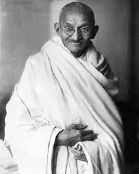

Gandhi was a campaigner for freedom and human rights.

## Dilution of Heroes:

> Cillian McHugh - 21/2/22

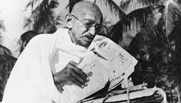

Gandhi was a campaigner for freedom and human rights, and he regularly read the newspaper.

## Dilution of Heroes:

> Cillian McHugh - 21/2/22

**Example 3:**

- DV: Hero perception
  - Diagnostic information: They have shown bravery, selflessness, and altruism throughout their life.
  - Non-diagnostic information: They are left-handed, drink tea in the morning, and have two older siblings and one younger sibling.
- *Eric had lovely results for this*

## Explaining the Dilution Effect

> Cillian McHugh - 21/2/22
- Representativeness heuristic and Category Typicality
- In categorization:
  - *furniture*: *chair* vs *bookend*
- Dilution and typicality
  - **Diagnostic information only**: Very representative (or typical)
  - **Non-Diagnostic information included**: Very less representative (or less typical)
- One prediction of MJAC is that moral categorizations should vary in typicality
  - Specifically, MJAC “predicts differences in typicality ratings when controlling for severity” (McHugh et al., 2022, p. 143)

## Moral Dilution

> Cillian McHugh - 21/2/22
- 2 studies
- Both Pre-registered
- Dilution effect should be observed for judgments of moral Character

## Pilot Study

## Pilot Study

> Cillian McHugh - 21/2/22
- Developing materials
- 6 descriptions:
  - 4 morally relevant (diagnostic)
  - 2 neutral (non-diagnostic)
- MTurk sample, *N* = 212, (female = 80, male = 128, non-binary = 1, prefer not to say = 1, *M<sub>age</sub>* = 36.6, *SD* = 10.3).

## Materials: Moral Descriptions

> Cillian McHugh - 21/2/22
- Imagine a person named Sam. Throughout their life they have been known to be cruel, act unfairly, and to betray their own group.
- Imagine a person named Robin. Throughout their life they have been known to physically hurt others, treat some people differently to others, and show lack of loyalty.
- Imagine a person named Francis. Throughout their life they have been known to violate the standards of purity and decency, show lack of respect for authority, and treat people unequally.
- Imagine a person named Alex. Throughout their life they have been known to cause others to suffer emotionally, to deny others their rights, and to cause chaos or disorder.

(adapted from Grizzard et al., 2020)

## Materials: Non-Diagnostic

> Cillian McHugh - 21/2/22
- Imagine a person named Jackie. They have red hair, play tennis four times a month, and have one older sibling and one younger sibling.
- Imagine a person named Charlie. They are left-handed, drink tea in the morning, and have two older siblings and one younger sibling.

## Measures:

> Cillian McHugh - 21/2/22
- DV1: Moral perceptions scale (Walker et al., 2021):
  - 7-point Likert
  - 4 items: Bad-Good, Moral-Immoral, Violent-Peaceful, Merciless-Empathetic
  - Cronbach’s alpha = 0.93
- DV2: Single item of moral perception (Walker et al., 2021).
  - 0-100 slider scale
  - Very Immoral-Very Moral

## Results (Single Item): Scenario

> Cillian McHugh - 21/2/22

```
## $ANOVA
##         Effect DFn  DFd       F            p p<.05        ges
## 2 scenario_abb   5 1055 55.7824 1.612454e-51     * 0.08327297
##
## $`Mauchly's Test for Sphericity`
##         Effect          W            p p<.05
## 2 scenario_abb 0.03844867 3.05385e-136     *
##
## $`Sphericity Corrections`
##         Effect       GGe        p[GG] p[GG]<.05       HFe        p[HF]
## 2 scenario_abb 0.3673207 1.275028e-20         * 0.3703898 9.017988e-21
##   p[HF]<.05
## 2         *
```

## Results (Single Item): Scenario

> Cillian McHugh - 21/2/22

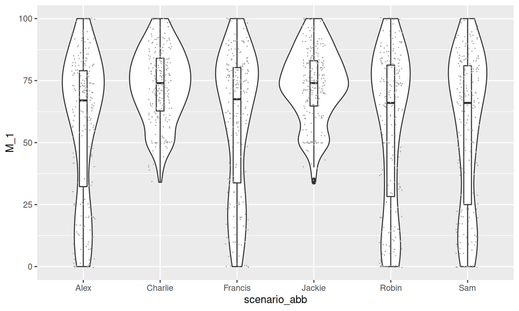

## Results (Single Item): Condition

> Cillian McHugh - 21/2/22

```
## [1] A paired samples t-test revealed a significant difference in moral Perception between the Diagnostic Condition, (M = 56.54, SD = 28.56), and the Non-Diagnostic condition, (M =72.97, SD = 13.89), t(211) = -8.735, p = 0, d = 0.6.
## NULL
```

A paired samples t-test revealed a significant difference in moral Perception between the Diagnostic Condition, (*M* = 56.54, *SD* = 28.56), and the Non-Diagnostic condition, (*M* =72.97, *SD* = 13.89), *t*(211) = -8.735, *p* < .001, *d* = 0.6.

## Results (Single Item): Condition

> Cillian McHugh - 21/2/22

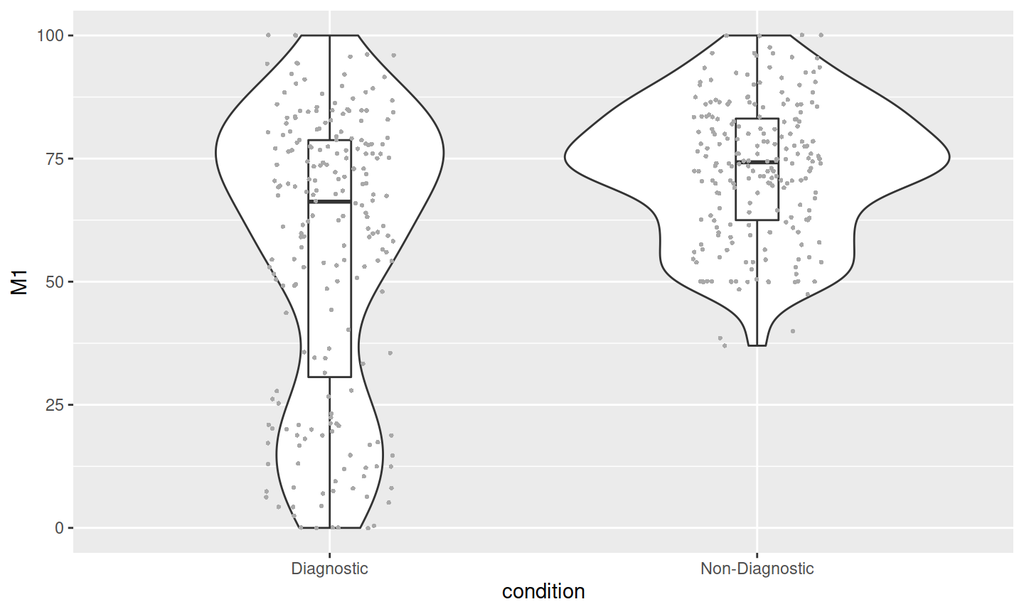

## Combined (Single Item - Condition & Scenario)

> Cillian McHugh - 21/2/22

```
##
## Error: ResponseId
##            Df Sum Sq Mean Sq F value Pr(>F)
## Residuals 211 558806    2648
##
## Error: ResponseId:condition
##            Df Sum Sq Mean Sq F value   Pr(>F)
## condition   1  76319   76319    76.3 7.58e-16 ***
## Residuals 211 211063    1000
## ---
## Signif. codes:  0 '***' 0.001 '**' 0.01 '*' 0.05 '.' 0.1 ' ' 1
##
## Error: ResponseId:scenario_abb
##               Df Sum Sq Mean Sq F value Pr(>F)
## scenario_abb   4   1012   253.0   2.621 0.0337 *
## Residuals    844  81447    96.5
## ---
## Signif. codes:  0 '***' 0.001 '**' 0.01 '*' 0.05 '.' 0.1 ' ' 1
```

## Results (Scale): Scenario

> Cillian McHugh - 21/2/22

```
## $ANOVA
##         Effect DFn  DFd        F            p p<.05       ges
## 2 scenario_abb   5 1055 53.13214 2.949287e-49     * 0.0770901
##
## $`Mauchly's Test for Sphericity`
##         Effect          W             p p<.05
## 2 scenario_abb 0.03499861 1.971032e-140     *
##
## $`Sphericity Corrections`
##         Effect       GGe        p[GG] p[GG]<.05      HFe        p[HF] p[HF]<.05
## 2 scenario_abb 0.3767718 3.199454e-20         * 0.380055 2.246887e-20         *
```

## Results (Scale): Scenario

> Cillian McHugh - 21/2/22

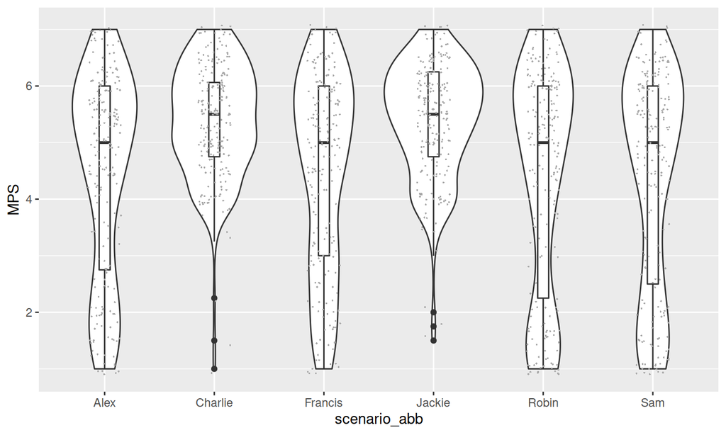

## Results (Scale): Condition

> Cillian McHugh - 21/2/22

## Results (Scale): Condition

> Cillian McHugh - 21/2/22

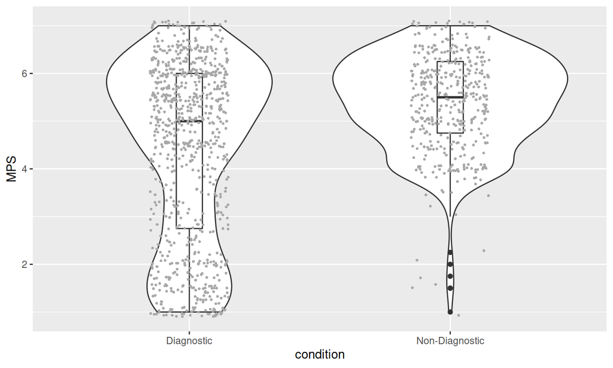

## Combined (Scale - Condition & Scenario)

> Cillian McHugh - 21/2/22

```
##
## Error: ResponseId
##            Df Sum Sq Mean Sq F value Pr(>F)
## Residuals 211   2215    10.5
##
## Error: ResponseId:condition
##            Df Sum Sq Mean Sq F value   Pr(>F)
## condition   1  274.6  274.56   74.92 1.27e-15 ***
## Residuals 211  773.3    3.66
## ---
## Signif. codes:  0 '***' 0.001 '**' 0.01 '*' 0.05 '.' 0.1 ' ' 1
##
## Error: ResponseId:scenario_abb
##               Df Sum Sq Mean Sq F value Pr(>F)
## scenario_abb   4    2.3  0.5746   1.487  0.204
## Residuals    844  326.2  0.3865
```

## Study 1

```
## [1] 283
```

## Study 1

> Cillian McHugh - 21/2/22

## Study 1: Design

- Within subjects design
  - IV: Diagnostic information (present/absent)
  - 4 descriptions
  - Randomly assigned to contain diagnostic information vs not
- Imagine a person named Sam. Throughout their life they have been known to be cruel, act unfairly, and to betray their own group.
- Imagine a person named Sam. Throughout their life they have been known to be cruel, act unfairly, and to betray their own group. *They are left-handed, drink tea in the morning, and have two older siblings and one younger sibling.*

## Materials: Moral Descriptions

> Cillian McHugh - 21/2/22
- Imagine a person named Sam. Throughout their life they have been known to be cruel, act unfairly, and to betray their own group.
- Imagine a person named Robin. Throughout their life they have been known to physically hurt others, treat some people differently to others, and show lack of loyalty.
- Imagine a person named Francis. Throughout their life they have been known to violate the standards of purity and decency, show lack of respect for authority, and treat people unequally.
- Imagine a person named Alex. Throughout their life they have been known to cause others to suffer emotionally, to deny others their rights, and to cause chaos or disorder.

## Materials: Non-Diagnostic

> Cillian McHugh - 21/2/22
- They have red hair, play tennis four times a month, and have one older sibling and one younger sibling.
- They are left-handed, drink tea in the morning, and have two older siblings and one younger sibling.

## Study 1

> Cillian McHugh - 21/2/22
- DV1: Moral perceptions scale (Walker et al., 2021):
  - 7-point Likert
  - 4 items: Bad-Good, Moral-Immoral, Violent-Peaceful, Merciless-Empathetic
  - Cronbach’s alpha = 0.83
- DV2: Single item of moral perception (Walker et al., 2021).
  - 0-100 slider scale
  - Very Immoral-Very Moral

UL Students with a total sample of *N* = 801, (female = 496, male = 283, non-binary/other = 17, prefer not to say 3, *M<sub>age</sub>* = 26.2, *SD* = 10.2).

## Results: Single Item Measure

> Cillian McHugh - 21/2/22

```
##                    numDF denDF   F-value p-value
## (Intercept)            1  2396 2180.9685  <.0001
## condition              1  2396   47.1470  <.0001
## scenario               3  2396  156.7080  <.0001
## condition:scenario     3  2396    2.0149  0.1098
```

## Main Effect for Condition (single item)

> Cillian McHugh - 21/2/22

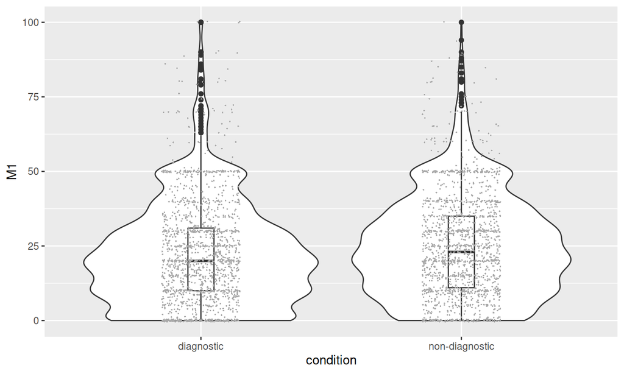

## Main Effect for Scenario (single item)

> Cillian McHugh - 21/2/22

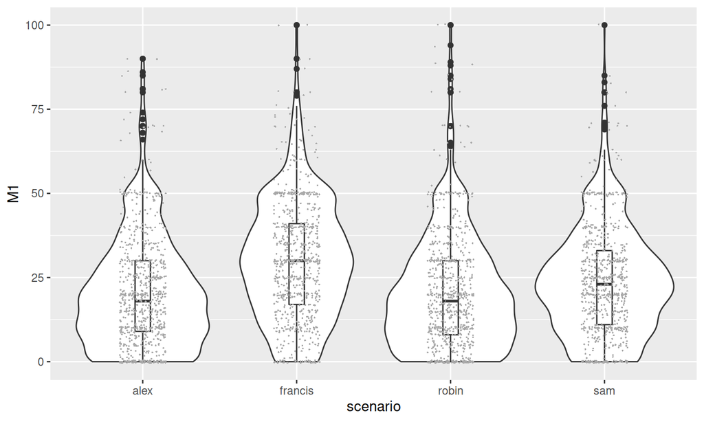

## Results: Scale

> Cillian McHugh - 21/2/22

```
##                    numDF denDF   F-value p-value
## (Intercept)            1  2396 10208.623  <.0001
## condition              1  2396    53.278  <.0001
## scenario               3  2396   304.146  <.0001
## condition:scenario     3  2396     0.997  0.3933
```

## Main Effect for Condition (scale)

> Cillian McHugh - 21/2/22

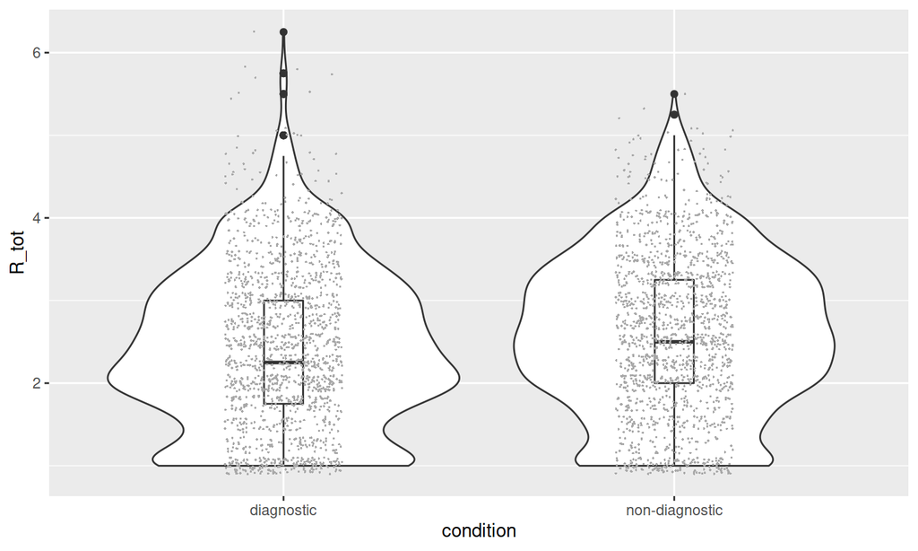

## Main Effect for Scenario (scale)

> Cillian McHugh - 21/2/22

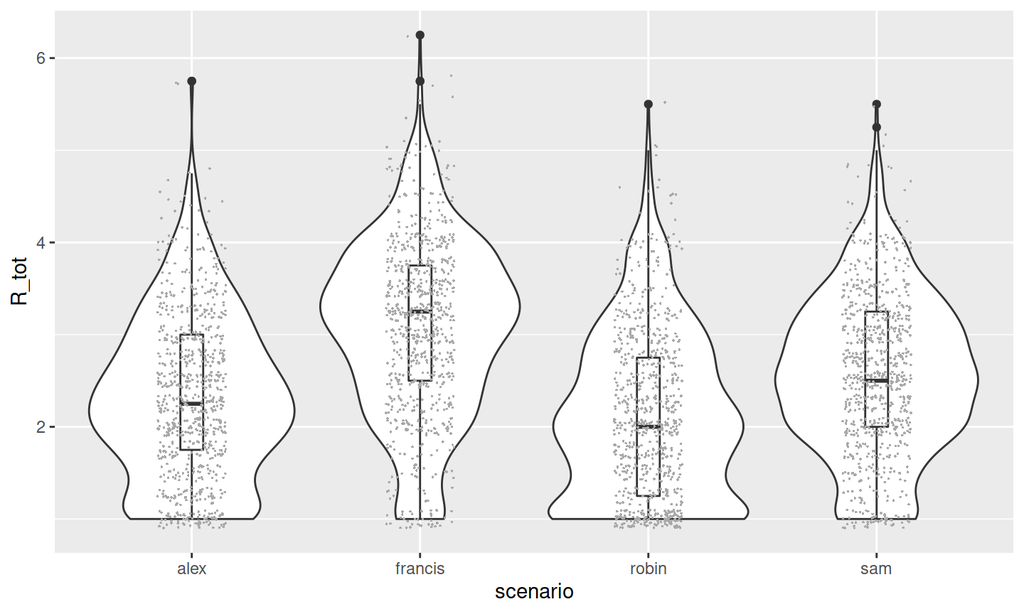

## Next Steps

## Next Steps

> Cillian McHugh - 21/2/22
- Thinking Styles Questionnaire?
  - Actively Open-minded Thinking
  - Close-Minded Thinking
  - Preference for Intuitive Thinking
  - Preference for Effortful Thinking